# projekt 1, faza 2

Julia Herman-Iżycka, Bartosz Sajniak, Jakub Tyrek, Rafał Zaborowski

April 11, 2016

## Data preparation:

- filter non-valid visitors
- count interaction time of each user with each station
- filter unusually long times - possible mistakes

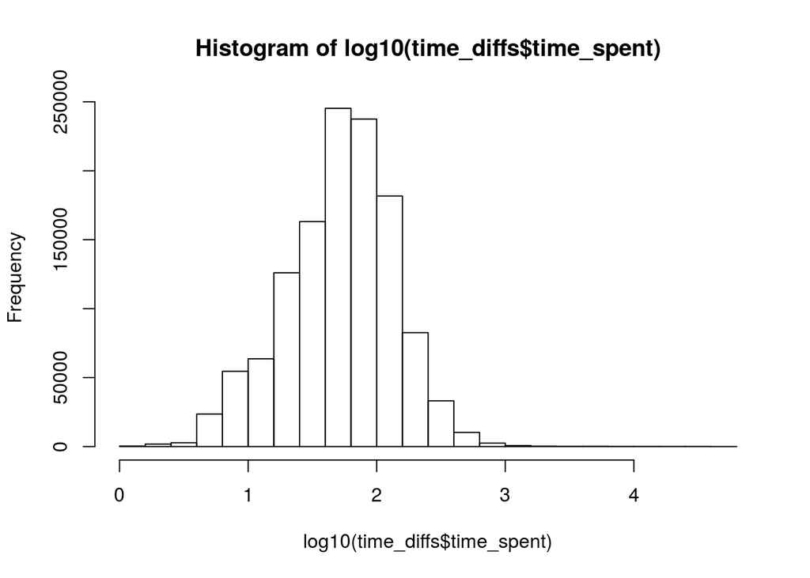

```r
smallLogs <- smallLogs %>% filter(visitor != -1)
smallLogs$visitor_change <- smallLogs$visitor != lag(smallLogs$visitor) | as.Date(smallLogs$date) != as.Date(lag(smallLogs$date)) | smallLogs$station != lag(smallLogs$station)

smallLogs$visitor_change[1] <- FALSE
smallLogs$visit_id <- cumsum(smallLogs$visitor_change)

time_diffs <- smallLogs %>% group_by(visit_id, station, visitor) %>% summarise(enter_time = first(date), leave_time = last(date), time_spent = leave_time - enter_time)

time_diffs$station <- factor(time_diffs$station)
time_diffs <- time_diffs %>% as_data_frame() %>% mutate(visitor_id = paste(visitor,  as.Date(enter_time), sep='_'))

hist(log10(time_diffs$time_spent))
```

```r
#filter unusually long times
upper_limit <- 10^4
time_diffs <- time_diffs  %>% filter(time_spent <= upper_limit)
```

## Compare time spent on different stations

We analyze distribution of time spent by visitors on visited stations

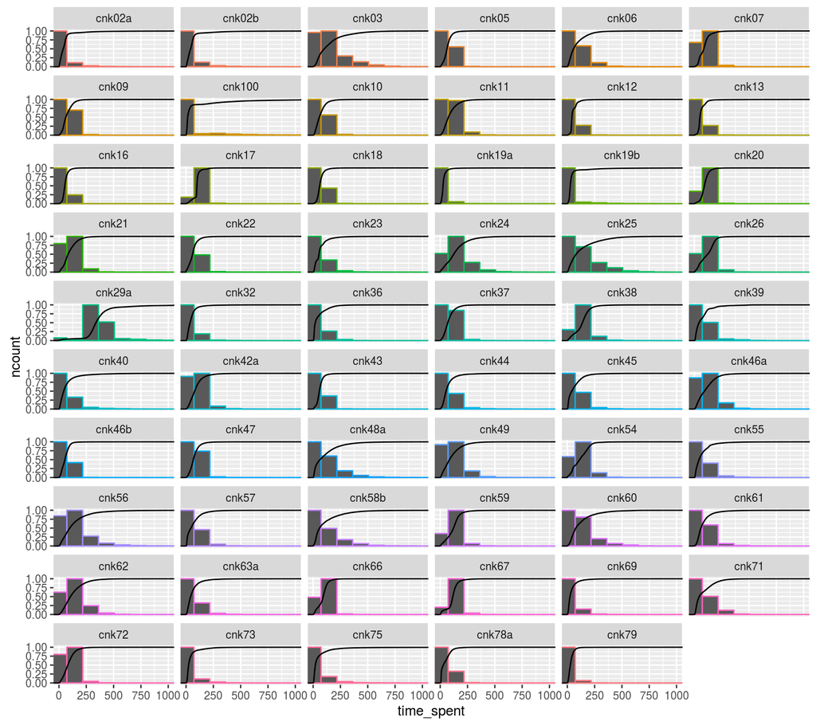

```r
time_spent <- aggregate(time_diffs$time_spent,list(time_diffs$visitor),median)

colnames(time_spent) <- c('visitor','mean_time_spent_visiting')

ggplot(time_diffs,aes(time_spent)) + geom_histogram(aes(y=..ncount..,colour=station, guided=FALSE),bins=70) + stat_ecdf() + facet_wrap(~ station,ncol=6) + coord_cartesian(xlim=c(0,1000)) + guides(colour=FALSE)
```

## Distances between stations

To create a similarity matrix of stations according to time spent by visitors, we use Kolmogorov-Smirnov test statistic to calculate similarity between two empirical cdf’s of visiting time distribution on given station.

```r
visit_time_range <- range(time_diffs$time_spent)
min_vt <- visit_time_range[[1]]
max_vt <- visit_time_range[[2]]
range_vt <- seq(min_vt,max_vt,by = 1)

by_station <- split(time_diffs$time_spent,time_diffs$station,drop=TRUE)
by_station_ecdf <- lapply(by_station, function(x){return(ecdf(x)(range_vt));})

dist_KS_mtx <- Vectorize(function(i,j){
  v1 <- by_station_ecdf[[i]];
  v2 <- by_station_ecdf[[j]];
  kst <- ks.test(v1,v2);
  s <- kst$statistic;
  names(s) <- NULL;
  return(s);
})

dist_mtx <- outer(1:length(by_station_ecdf),1:length(by_station_ecdf),dist_KS_mtx)

station_names <- time_diffs %>% distinct(station) %>% dplyr::select(station)
```

## Determine number of clusters

We now want to cluster stations based on distance matrix. To establish proper number of cluters we may use:

1. Mean silhouetes:

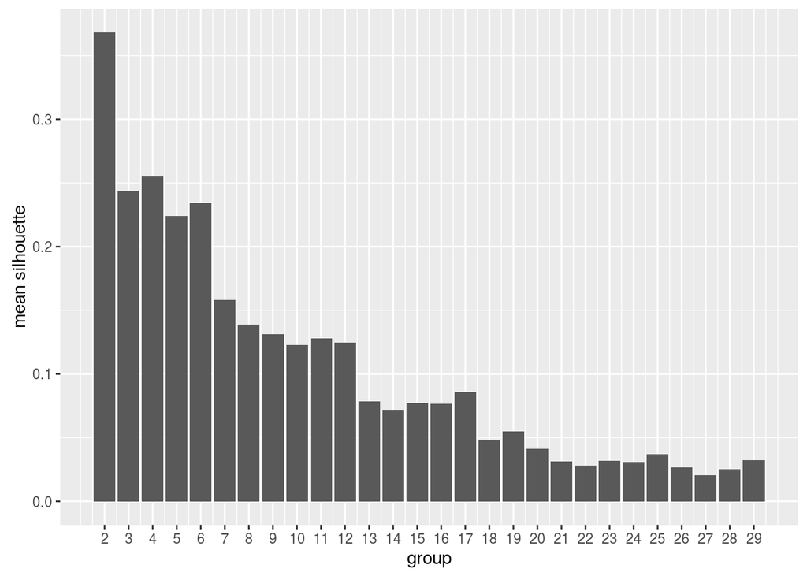

```r
sils <- data.frame()
for(i in 2:(nrow(dist_mtx)/2)){
  paths_pam <- pam(dist_mtx, i);
  sil <- silhouette(paths_pam$clustering,dist_mtx);
  sils <- rbind(sils,data.frame(group=i,mean_silhouette=mean(sil[,"sil_width"]),std_silhouette=sd(sil[,"sil_width"])));
}

ggplot(sils,aes(group,mean_silhouette)) + geom_bar(stat="identity") + scale_x_continuous(breaks = seq(2,29,1)) + ylab("mean silhouette")
```

2. Gap statistic:

```r
library("factoextra")

clusters_eclust <- eclust(dist_mtx,"agnes",graph=FALSE)
data.frame(station=station_names$station, cluster=clusters_eclust$cluster)
```

```
##    station cluster
## 1   cnk02a       1
## 2   cnk02b       2
## 3    cnk03       1
## 4    cnk05       3
## 5    cnk06       1
## 6    cnk07       3
## 7    cnk09       4
## 8   cnk100       5
## 9    cnk10       6
## 10   cnk11       7
## 11   cnk12       4
## 12   cnk13       6
## 13   cnk16       7
## 14   cnk17       4
```

[output cut: 45 more lines]

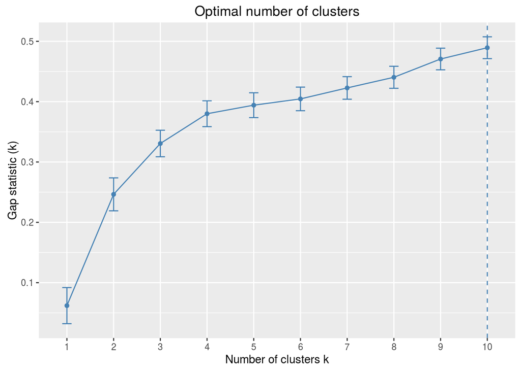

```r
fviz_gap_stat(clusters_eclust$gap_stat)
```

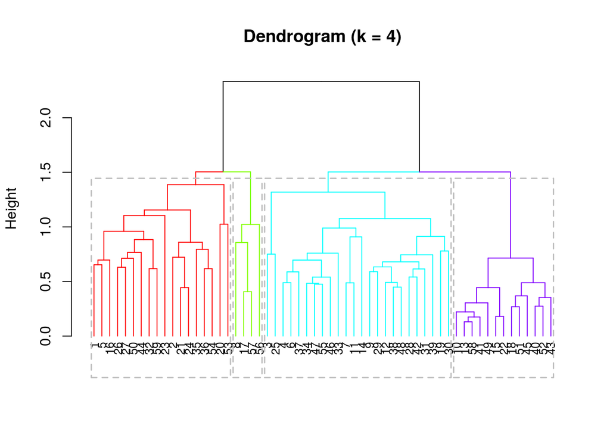

```r
clusters <- agnes(dist_mtx)
fviz_dend(clusters, k = 4, rect = TRUE, main = "Dendrogram (k = 4)")
```

## Stations distances

Let’s visualise the stations’ distances using PCA. First, let’s compute the variance preserved, then cluster the points using hierarchical clustering and pam.

```r
station_pca <- cmdscale(dist_mtx, eig = TRUE)
print((station_pca$eig[1] ^ 2 + station_pca$eig[2] ^ 2) / (sum(sapply(station_pca$eig, function(x) x ^ 2))))
```

```
## [1] 0.895935
```

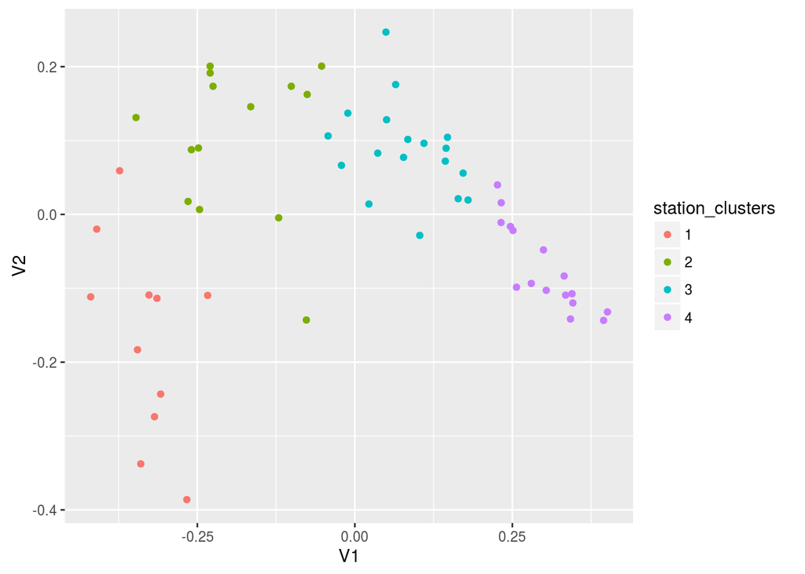

```r
station_pam <- pam(dist_mtx, 4)
station_clusters <- sapply(station_pam$clustering, toString)
ggplot(as.data.frame(station_pca$points), aes(V1, V2)) + geom_point(aes(color = station_clusters))
```

The distance is computed from the spent time distribution only. Next plots presents how these distributions differ.

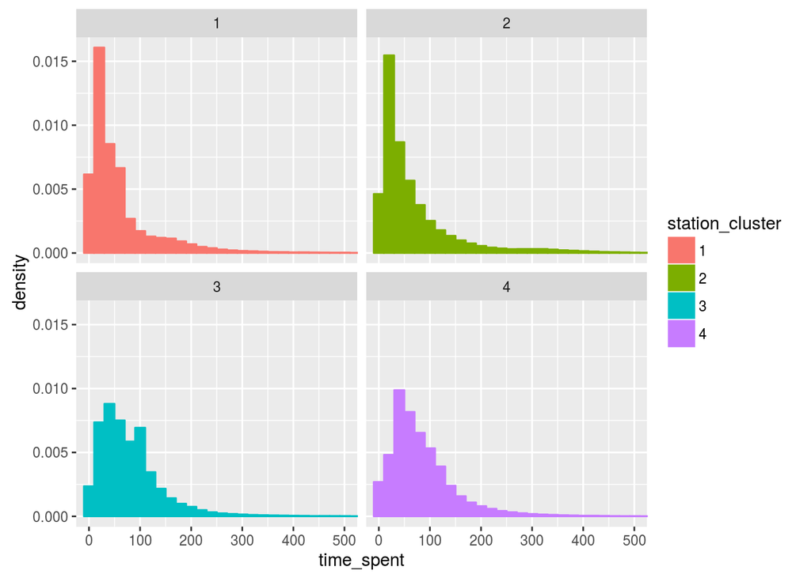

```r
station_names <- station_names %>% mutate(cluster = station_clusters)
time_diffs <- time_diffs %>% mutate(station_cluster = plyr::mapvalues(station, as.vector(station_names$station), as.vector(station_names$cluster)))

ggplot(time_diffs, aes(time_spent, color = station_cluster, fill = station_cluster)) + geom_histogram(aes(y = ..density..), bins = 500) + facet_wrap(~station_cluster) + coord_cartesian(xlim = c(0, 500))
```

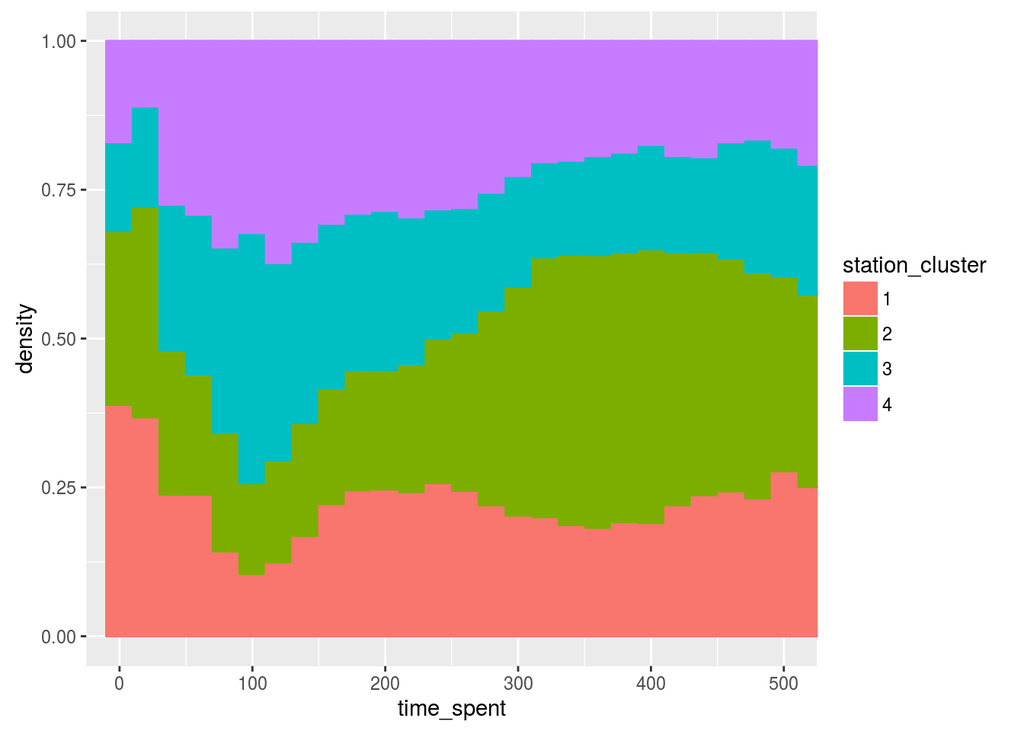

```r
ggplot(time_diffs, aes(time_spent, color = station_cluster, fill = station_cluster)) + geom_histogram(aes(y = ..density..), bins = 500, position = 'fill') + coord_cartesian(xlim = c(0, 500))
```

# Analysis of paths - how people move around exhibition?

## Paths preparation.

For string distance, such as Levenstein distance, we need to denote names of stations using one letter. We also exclude paths shorter than 10. We do not use Levenstein (or any other similar), since paths are too different

```r
station_names <- time_diffs %>% distinct(station) %>% dplyr::select(station)
station_names <- station_names %>% mutate(station_char = c(letters, LETTERS, 1:7)) #na sztywno

time_diffs <- time_diffs %>% ungroup() %>% arrange(visitor, enter_time)
time_diffs <- time_diffs %>% mutate(station_char = plyr::mapvalues(station, as.vector(station_names$station), as.vector(station_names$station_char)))

paths <- time_diffs %>% group_by(visitor, date = as.Date(enter_time)) %>% summarise(path = paste(station_char, collapse = ''))
paths <- paths %>% mutate(n = nchar(path))
paths <- paths %>% filter(n >= 10)
```

We use similarity of station visit profile as a distance between paths. Count distance using substitution matrix = similarity of cdf of times spent at station. We sample 1000 paths with length equal to 10 because distance matrix is otherwise too big.

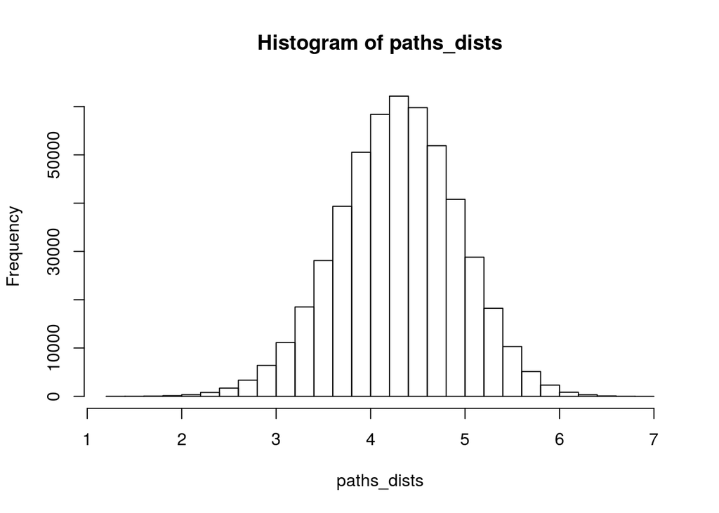

```r
paths2 <- paths %>%  filter(n == 10) %>% ungroup() %>% sample_n(size=1000)

row.names(dist_mtx) <- station_names$station_char
colnames(dist_mtx) <- station_names$station_char

paths_dists <- stringDist(paths2$path,method="substitutionMatrix",
  substitutionMatrix = dist_mtx
)

hist(paths_dists)
```

## Frequent connections in paths

Single step probability - we count most frequent connections between stations, conditioning on frequency of first station from pair (we estimate conditional probability).

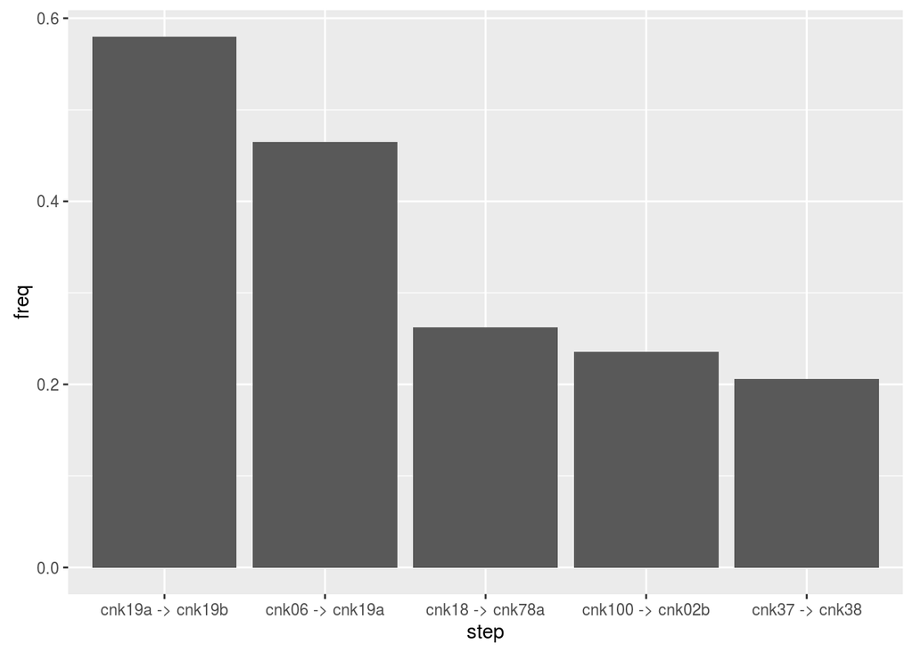

```r
time_diffs$day_or_visitor_changed <- as.Date(time_diffs$enter_time) != as.Date(lag(time_diffs$enter_time)) | time_diffs$visitor != lag(time_diffs$visitor)
time_diffs$day_or_visitor_changed[1] <- FALSE

time_diffs$prev_station <- lag(time_diffs$station)
time_diffs <- time_diffs %>% mutate(prev_station = replace(prev_station, day_or_visitor_changed, NA))

vis_seq <- time_diffs %>% filter(!is.na(prev_station)) %>% group_by(prev_station, station) %>% summarise(n = n()) %>% mutate(freq = n / sum(n))
vis_seq <- vis_seq %>% ungroup() %>% dplyr::arrange(desc(freq)) %>% dplyr::slice(1:5)
vis_seq <- vis_seq %>% transmute(step = paste(prev_station, station, sep = ' -> '), freq = freq)
vis_seq <- vis_seq %>% mutate(step = factor(step, levels = vis_seq$step[order(freq, decreasing = TRUE)]))

ggplot(vis_seq, aes(step, freq)) + geom_bar(stat = 'identity')
```

## MDS

We perform non-metric Multidimensional Scaling and plot Shepard plot.

```r
newcoord <- isoMDS(as.dist(paths_dists))
```

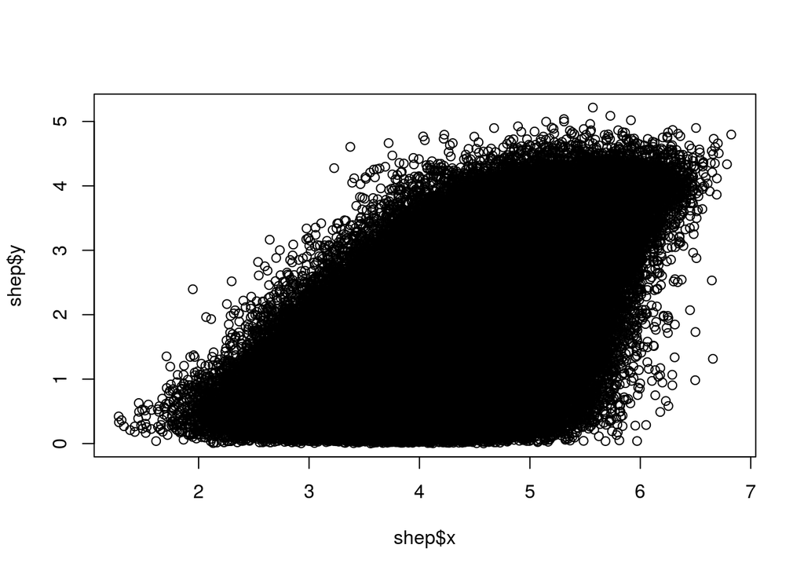

```r
#plot(newcoord$points)

shep <- Shepard(paths_dists, newcoord$points)
plot(shep)
```

```r
df2 <- data.frame(x = newcoord$points[,1], y = newcoord$points[,2])
```

## Cluster paths

We try to cluster using k-medoids as well as hierarchical clustering, although we don’t see clusters on plots after transforming into 2D. But Shepard plots look bad, so transformation is not informative.

```r
#k-medoids
kmedoids <- pam(paths_dists, 4)
df2$cluster <- as.factor(kmedoids$clustering)

print(paths2[kmedoids$medoids,])
```

```
## Source: local data frame [4 x 4]
##
##   visitor       date       path     n
##     (chr)     (date)      (chr) (int)
## 1  857811 2012-02-04 epqjUVE3BX    10
## 2 1051194 2012-05-03 adgYmrVV3E    10
## 3  881812 2012-02-17 baZnyHWQPM    10
## 4  853302 2012-02-02 66VE7MCBLK    10
```

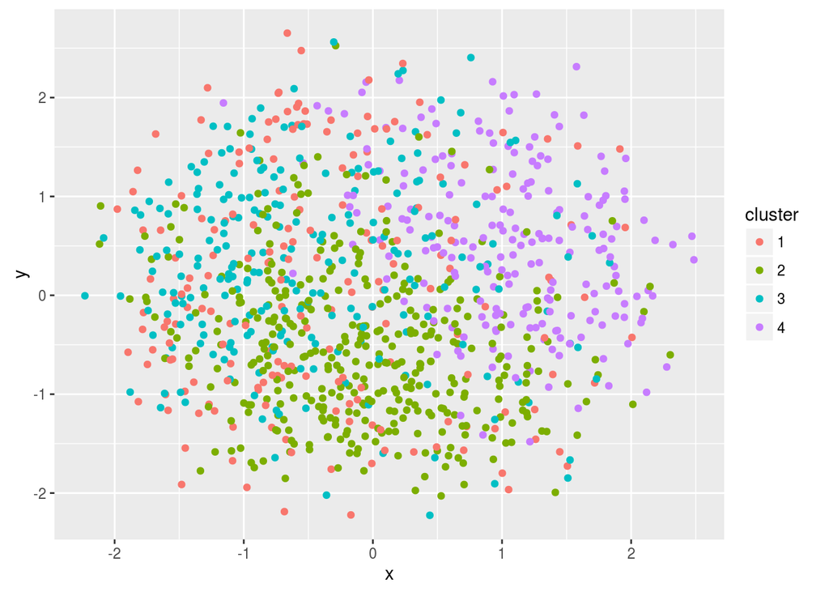

```r
ggplot(df2, aes(x=x, y=y)) + geom_point(aes(color=cluster))
```

```r
#hierarchical clustering
tree1 <- agnes(paths_dists, method = "ward")
clusters <- factor(cutree(tree1, 4))

summary(clusters)
```

```
##   1   2   3   4
## 274 199 373 154
```

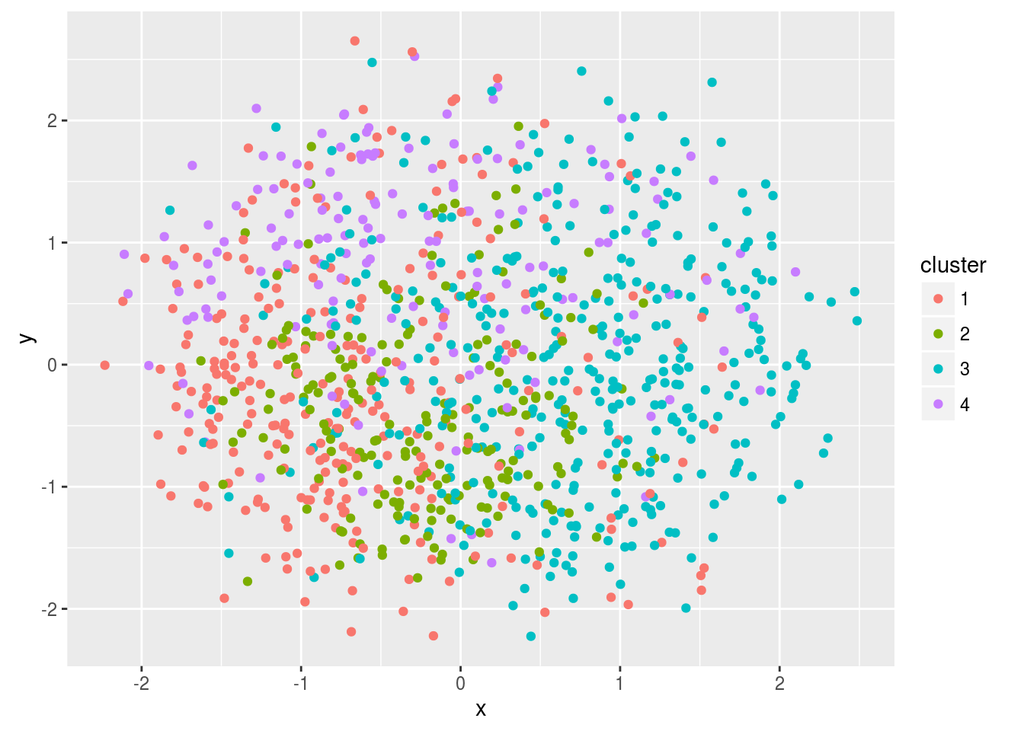

```r
df2$cluster <- clusters
ggplot(df2, aes(x=x, y=y)) + geom_point(aes(color=cluster))
```

## Stations in path clusters

We analyze clusters from k-medoids clustering - how often each station occurs in paths from clusters.

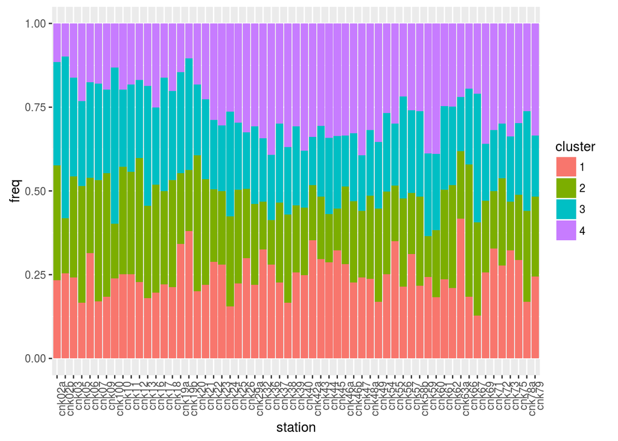

```r
get_freq_ch <- function(st_ch){
  paths2 <- paths2 %>% mutate(got_st_ch = grepl(st_ch, path), cluster = kmedoids$clustering)
  paths2_sum <- paths2 %>% group_by(cluster) %>% summarise(ch_freq = sum(got_st_ch) / n())
  return(paths2_sum$ch_freq)
}

ch_freqs <- c()
for(i in 1:dim(station_names)[1]){
  t1 <- c(get_freq_ch(station_names[i,2]))
  ch_freqs <- rbind(ch_freqs, t1)
}

colnames(ch_freqs) <- 1:4
ch_freqs <- as.data.frame(ch_freqs)
ch_freqs$station <- station_names$station
ch_freqs <- gather(ch_freqs, cluster, freq, 1:4)

ggplot(ch_freqs, aes(station, freq)) + geom_bar(position = 'fill', stat = 'identity', aes(fill = cluster)) + theme(axis.text.x = element_text(angle = 90, hjust = 1))
```